# #backOfaFagPacket: Its the Cats, stupid

Does cat ownership correlate with home energy demand?

Ben Anderson

Last run at: 2021-12-06 23:34:45

> This fridayFagPacket was first published at…

# 1 fridayFagPackets

Numbers that could have been done on the back of one and should probably come with a similar health warning…

> Find out [more](https://dataknut.github.io/fridayFagPackets/).

# 2 It’s the cats, stupid

Inspired by `@giulio_mattioli`’s [recent paper on the car dependence of dog ownership](https://twitter.com/giulio_mattioli/status/1466361022747455492) we thought we’d take a look at [cats](https://twitter.com/giulio_mattioli/status/1466710752606179331) and residential energy demand. Why? Well people like to keep their cats warm but, more importantly, they also cut big holes in doors and/or windows to let the cats in and out. Hardly a thermally sealed envelope…

# 3 What’s the data?

We could also use `@SERL_UK`’s [smart meter gas/elec data](https://twitter.com/dataknut/status/1466712963222540289?s=20), dwelling characteristics and pet ownership (but no species detail :-)

So for now we’re using:

- postcode district level estimates of cat ownership in the UK in 2015. Does such a thing exist? [YEAH](https://data.gov.uk/dataset/febd29ff-7e7d-4f82-9908-031f7f0e0860/cat-population-per-postcode-district)! “*This dataset gives the mean estimate for population for each district, and was generated as part of the delivery of commissioned research. The data contained within this dataset are modelled figures, based on national estimates for pet population, and available information on Veterinary activity across GB. The data are accurate as of 01/01/2015. The data provided are summarised to the postcode district level. Further information on this research is available in a research publication by James Aegerter, David Fouracre & Graham C. Smith, discussing the structure and density of pet cat and dog populations across Great Britain.*”
- experimental postcode level data on domestic [gas](https://www.gov.uk/government/collections/sub-national-gas-consumption-data) and [electricity](https://www.gov.uk/government/collections/sub-national-electricity-consumption-data) ‘consumption’ for 2015 aggregated to postcode districts

```r
# cats
cats_DT <- data.table::fread(paste0(dp, "UK_Animal and Plant Health Agency/APHA0372-Cat_Density_Postcode_District.csv"))
cats_DT[, pcd_district := PostcodeDistrict]

setkey(cats_DT, pcd_district)

nrow(cats_DT)
```

```
## [1] 2830
```

```r
setkey(pc_district_energy_dt, pcd_district)

nrow(pc_district_energy_dt)
```

```
## [1] 3185
```

```r
pc_district <- pc_district_energy_dt[cats_DT] # keeps only postcode districts where we have cat data
# this may include areas where we have no energy data
pc_district[, mean_Cats := EstimatedCatPopulation/nElecMeters]

nrow(pc_district)
```

```
## [1] 2987
```

```r
nrow(pc_district[!is.na(GOR10NM)])
```

```
## [1] 2936
```

```r
# there are postcode districts with no electricity meters - for now we'll remove them
# pending further investigation

t <- pc_district[!is.na(GOR10NM), .(nPostcodeDistricts = .N,
                     sumCats = sum(EstimatedCatPopulation)), keyby=.(GOR10NM)]

t[, catsPerDistrict := sumCats/nPostcodeDistricts]
makeFlexTable(t, cap = "Regions covered")
```

Table 3.1: Regions covered

| GOR10NM | nPostcodeDistricts | sumCats | catsPerDistrict |
| --- | --- | --- | --- |
| (pseudo) Scotland | 419 | 997,963.9 | 2,381.8 |
| (pseudo) Wales | 199 | 728,109.6 | 3,658.8 |
| East Midlands | 163 | 819,002.6 | 5,024.6 |
| East of England | 262 | 1,138,362.7 | 4,344.9 |
| London | 295 | 602,199.5 | 2,041.4 |
| North East | 130 | 390,408.6 | 3,003.1 |
| North West | 288 | 1,032,288.2 | 3,584.3 |
| South East | 412 | 1,804,589.1 | 4,380.1 |
| South West | 288 | 1,488,017.7 | 5,166.7 |
| West Midlands | 243 | 989,675.6 | 4,072.7 |
| Yorkshire and The Humber | 237 | 936,527.3 | 3,951.6 |

# 4 What do we find?

Well, in some places there seem to be a lot of estimated cats per household…

(We calculated mean cats per household by dividing by the number of electricity meters - probably a reasonable proxy)

```r
t <- head(pc_district[, .(PostcodeDistrict, EstimatedCatPopulation, mean_Cats, nPostcodes, nElecMeters)][order(-mean_Cats)],10)
makeFlexTable(t, cap = "Top 10 postcode districts by number of cats per 'household'")
```

Table 4.1: Top 10 postcode districts by number of cats per ‘household’

| PostcodeDistrict | EstimatedCatPopulation | mean_Cats | nPostcodes | nElecMeters |
| --- | --- | --- | --- | --- |
| SA63 | 1,981.1 | 13.9 | 7 | 143 |
| LL23 | 8,233.1 | 10.6 | 21 | 778 |
| LL66 | 104.7 | 9.5 | 1 | 11 |
| BS28 | 4,034.6 | 8.9 | 31 | 451 |
| LA17 | 1,341.8 | 8.9 | 2 | 151 |
| EH25 | 7,489.8 | 8.9 | 17 | 843 |
| CA9 | 1,819.9 | 8.2 | 23 | 223 |
| SA66 | 3,298.3 | 7.9 | 14 | 419 |
| LL24 | 1,388.6 | 7.0 | 18 | 197 |
| LA20 | 1,598.1 | 6.6 | 7 | 241 |

SA63 is in south west [Wales](https://www.google.co.uk/maps/place/Clarbeston+Road+SA63/@51.8852685,-4.9147384,12z/data=!3m1!4b1!4m5!3m4!1s0x4868d5805b12efe5:0xca42ee4bc84a2f77!8m2!3d51.8900045!4d-4.8502065) while LL23 is on the edge of the [Snowdonia National Park](https://www.google.co.uk/maps/place/Bala+LL23/@52.8953768,-3.7752989,11z/data=!3m1!4b1!4m5!3m4!1s0x4865404ae1208f67:0x65a437b997c0dfb2!8m2!3d52.8825403!4d-3.6497989)….

Do these places have some largish catteries but few houses? 8,233 is a lot of estimated cats.

## 4.1 More dwellings, more cats?

Is there a correlation between estimated total cats and the number of dwellings (electricity meters)?

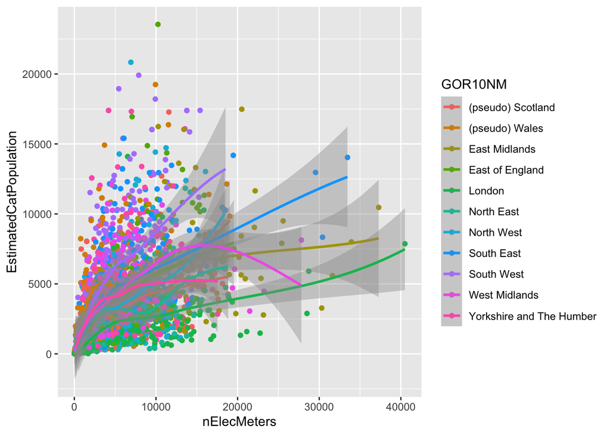

```r
ggplot2::ggplot(pc_district[!is.na(GOR10NM)], aes(x = nElecMeters , y = EstimatedCatPopulation,
                                 colour = GOR10NM)) +
  geom_point() +
  geom_smooth()
```

## 4.2 More cats, more gas?

Is there a correlation between estimated cat ownership and total gas use?

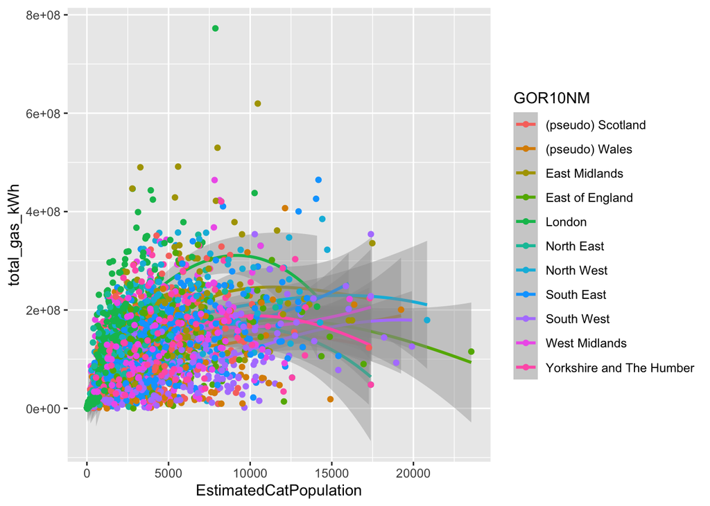

```r
ggplot2::ggplot(pc_district[!is.na(GOR10NM)],
                aes(x = EstimatedCatPopulation, y = total_gas_kWh, colour = GOR10NM)) +
  geom_smooth() +
  geom_point()
```

Or mean gas use and mean cats?

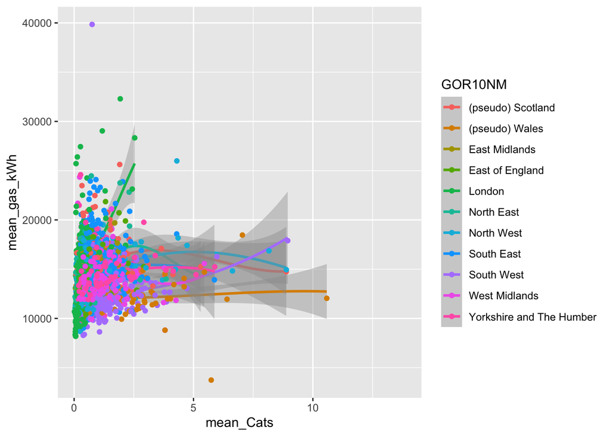

```r
ggplot2::ggplot(pc_district[!is.na(GOR10NM)],
                aes(x = mean_Cats, y = mean_gas_kWh, colour = GOR10NM)) +
  geom_smooth() +
  geom_point()
```

## 4.3 More cats, more electricity?

Or total electricity use and cats?

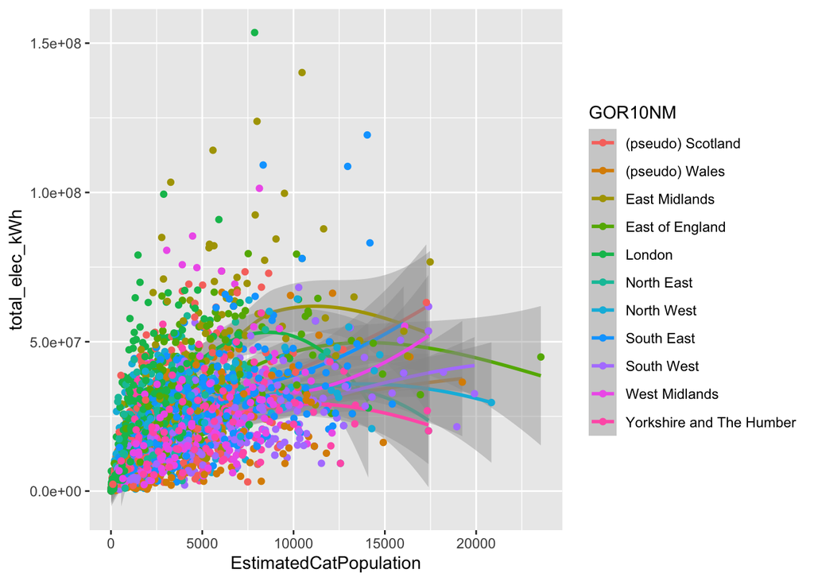

```r
ggplot2::ggplot(pc_district[!is.na(GOR10NM)], aes(x = EstimatedCatPopulation, y = total_elec_kWh, colour = GOR10NM)) +
  geom_smooth() +
  geom_point()
```

Or mean elec use and mean cats?

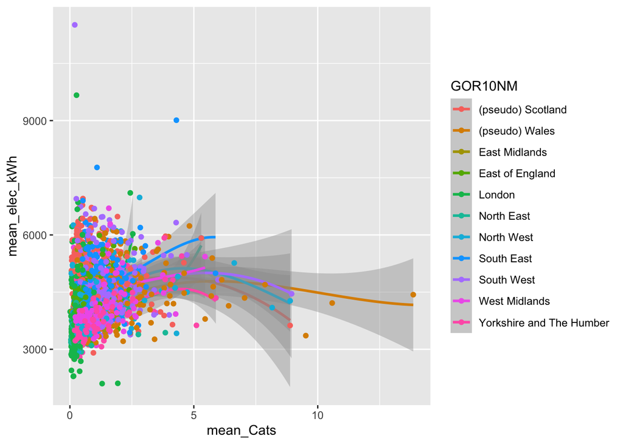

```r
ggplot2::ggplot(pc_district[!is.na(GOR10NM)], aes(x = mean_Cats, y = mean_elec_kWh, colour = GOR10NM)) +
  geom_smooth() +
  geom_point()
```

## 4.4 More cats, more energy?

Or total energy use and total cats?

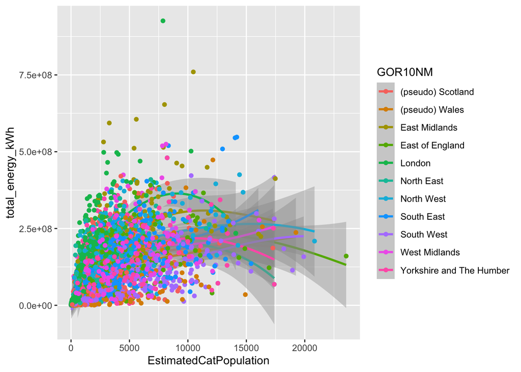

```r
pc_district[, total_gas_kWh := ifelse(is.na(total_gas_kWh), 0, total_gas_kWh)]
pc_district[, total_energy_kWh := total_gas_kWh + total_elec_kWh]
pc_district[, mean_energy_kWh := total_energy_kWh/nElecMeters]

ggplot2::ggplot(pc_district[!is.na(GOR10NM)], aes(x = EstimatedCatPopulation, y = total_energy_kWh, colour = GOR10NM)) +
  geom_smooth() +
  geom_point()
```

Let’s try a boxplot by cat deciles… Figure 4.1 suggests the median energy use is higher in postcode districts with higher cat ownership.

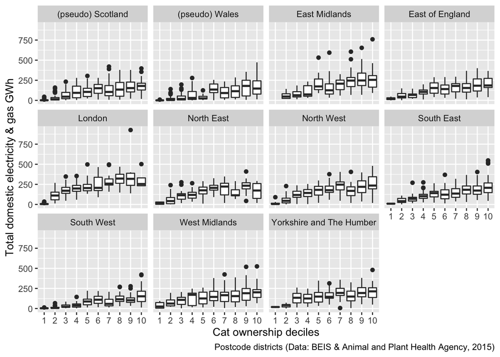

Figure 4.1: Cat ownership deciles and total annual residenital electricity & gas use

```r
pc_district[, cat_decile := dplyr::ntile(EstimatedCatPopulation, 10)]
#head(pc_district[is.na(cat_decile)])
ggplot2::ggplot(pc_district[!is.na(cat_decile) & !is.na(GOR10NM)], aes(x = as.factor(cat_decile), y = total_energy_kWh/1000000)) +
  geom_boxplot() +
  facet_wrap(. ~ GOR10NM) +
  labs(x = "Cat ownership deciles",
       y = "Total domestic electricity & gas GWh",
       caption = "Postcode districts (Data: BEIS & Animal and Plant Health Agency, 2015)")
```

Well…

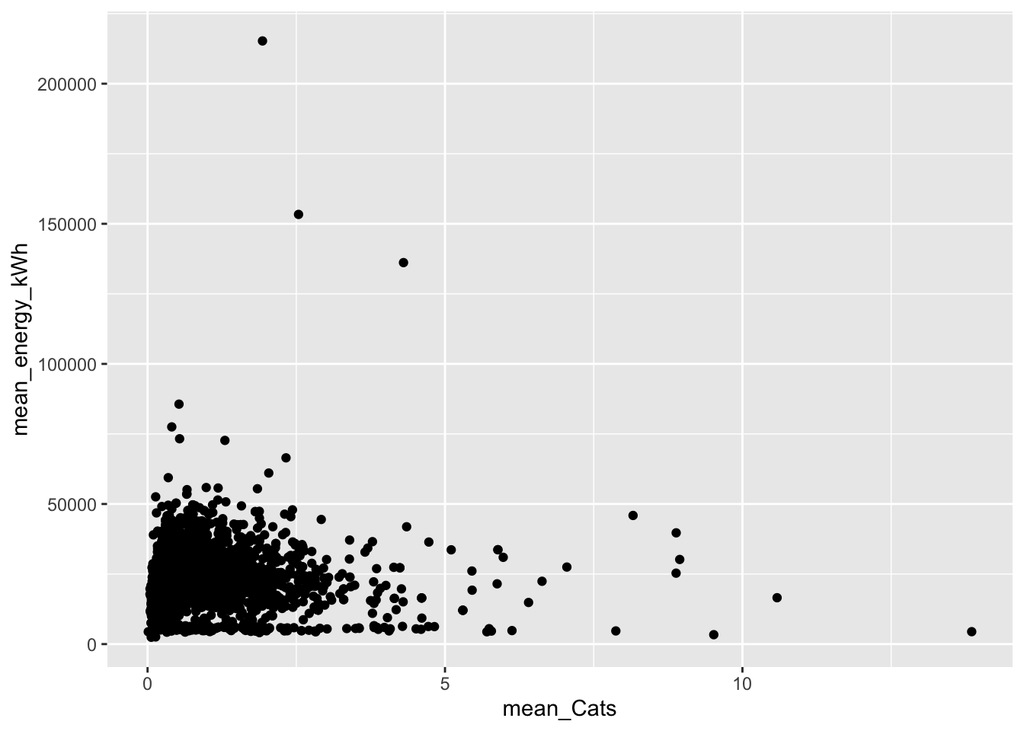

```r
pc_district[, total_energy_kWh := total_gas_kWh + total_elec_kWh]
pc_district[, mean_energy_kWh := total_energy_kWh/nElecMeters]

ggplot2::ggplot(pc_district[!is.na(GOR10NM)], aes(x = mean_Cats, y = mean_energy_kWh)) +
  geom_point()
```

# 5 R packages used

- bookdown (Xie 2016a)
- data.table (Dowle et al. 2015)
- ggplot2 (Wickham 2009)
- knitr (Xie 2016b)
- rmarkdown (Allaire et al. 2018)

# References

Allaire, JJ, Yihui Xie, Jonathan McPherson, Javier Luraschi, Kevin Ushey, Aron Atkins, Hadley Wickham, Joe Cheng, and Winston Chang. 2018. *Rmarkdown: Dynamic Documents for r*. https://CRAN.R-project.org/package=rmarkdown.

Dowle, M, A Srinivasan, T Short, S Lianoglou with contributions from R Saporta, and E Antonyan. 2015. *Data.table: Extension of Data.frame*. https://CRAN.R-project.org/package=data.table.

Wickham, Hadley. 2009. *Ggplot2: Elegant Graphics for Data Analysis*. Springer-Verlag New York. http://ggplot2.org.

Xie, Yihui. 2016a. *Bookdown: Authoring Books and Technical Documents with R Markdown*. Boca Raton, Florida: Chapman; Hall/CRC. https://github.com/rstudio/bookdown.

———. 2016b. *Knitr: A General-Purpose Package for Dynamic Report Generation in r*. https://CRAN.R-project.org/package=knitr.